# Проект - Выбор локации для скважины

## Обучение и проверка модели

Создадим функцию, которая примет список датасетов и вернет предсказанные и истинные значения валидационной выборки каждой модели. Также для каждой модели выведем среднее значение и RMSE.

```python
def region_linear_models(list_of_df):
    region_dict = {} # инициализируем словарь в котором каждому региону будет соответствовать список y_valid и y_pred
    for i, df in enumerate(list_of_df):

        # разделим датасет на признаки и таргет
        X = df.drop('product', axis=1)
        y = df['product']

        # разобьем выборки на тренировочную и валидационную часть
        X_train, X_valid, y_train, y_valid = train_test_split(X, y, test_size=VALID_SIZE, random_state=STATE)

        # инициализируем модель линейной регрессии и обучим её на тренировочных данных
        model = make_pipeline(StandardScaler(), LinearRegression())
        model.fit(X_train, y_train)

        # предскажем значения, используя модель, и для удобства переведем их в вид Series
        y_pred = model.predict(X_valid)
        y_pred = pd.Series(y_pred)

        # найдем среднее значение по предсказанным данным и RMSE
        mean_product = y_pred.mean()
        rmse = mean_squared_error(y_valid, y_pred, squared=False)

        # выведем полученные значения для каждого региона
        print(f'Регион {i+1}:')
        print(f'Средний запас предсказанного сырья - {mean_product:.2f} тыс.баррелей\nRMSE - {rmse:.2f} тыс.баррелей\n')

        # добавим в словарь region_dict ключ по номеру региона и списком значений y_valid и y_true
        region_dict[f'region {i}'] = []
        region_dict[f'region {i}'].append(y_valid)
        region_dict[f'region {i}'].append(y_pred)

    return region_dict
```

```python
dict_of_regions = region_linear_models(list_of_df)
```

```
Регион 1:
Средний запас предсказанного сырья - 92.59 тыс.баррелей
RMSE - 37.58 тыс.баррелей

Регион 2:
Средний запас предсказанного сырья - 68.77 тыс.баррелей
RMSE - 0.89 тыс.баррелей

Регион 3:
Средний запас предсказанного сырья - 95.09 тыс.баррелей
RMSE - 39.96 тыс.баррелей
```

По полученным данным видно, что наибольшие средние запасы нефти находятся в **третьем** регионе (95,09 тыс.баррелей), далее запасы **первого** региона (92,59 тыс. баррелей) и существенно уступает **второй** регион со средними запасами в 68,77 тыс.баррелей.

Также можно заметить, что RMSE модели первого и третьего региона имеют примерно похожие значения, в то время как RMSE модели второго региона имеет значение близкое к нулю.

Можно предположить, что модель для второго региона переобучилась, а причина этому, это признак `f2`, имеющий коэффициент корреляции Пирсона, равный 1 с таргет-переменной.

**Вывод:** В ходе обучения и проверки моделей были получены следующие результаты:

- Наибольшие средние запасы нефти находятся в третьем регионе (95,09 тыс.баррелей), далее запасы первого региона (92,59 тыс. баррелей) и существенно уступает второй регион со средними запасами в 68,77 тыс.баррелей.

## Подготовка к расчёту прибыли

Обозначим все необходимые переменные для расчета прибыли.

```python
income_per_unit = 450000 # доход с каждой единицы продукта
exploration_budget = 1e10 # бюджет на разработку скважин в регионе
num_of_spots = 500 # количество точек при исследовании региона
num_of_best_spots = 200 # количество необходимых выбранных точек с помощью м.о.
```

```python
break_even_point = exploration_budget / income_per_unit
print(f'Точка безубыточности добычи для всех скважин в каждом регионе  - {break_even_point:.0f} тыс.баррелей')
print(f'Точка безубыточности добычи для одной скважины во всех регионах - {break_even_point / 200:.2f} тыс.баррелей')
```

```
Точка безубыточности добычи для всех скважин в каждом регионе  - 22222 тыс.баррелей
Точка безубыточности добычи для одной скважины во всех регионах - 111.11 тыс.баррелей
```

**Вывод:**

Среднее значение запаса сырья по всем скважинам для каждого из регионов меньше, чем точка безубыточности: 111 тыс. баррелей (объём сырья для безубыточной разработки новой скважины), поэтому разработку всех скважин вести нерентабельно. Для задачи нужно выбрать всего 200 лучших с максимальными запасами и вкладывать деньги в их запуск.

## Расчёт прибыли и рисков

Напишем функцию для расчёта прибыли по выбранным скважинам и предсказаниям модели.

```python
# функция принимает датасет, истинные значения и предсказанные значения, а также константы, инициализированные ранее
def region_income(df, y_true, y_pred,
                  n_best=num_of_best_spots,
                  income_per_unit=income_per_unit,
                  cost_of_exp=exploration_budget):

    y_true.reset_index(drop=True, inplace=True)
    # отсортируем скажины по предсказанным значениям в порядке убывания
    sorted_wells= y_pred.reset_index(drop=True).sort_values(ascending=False)
    # выберем n_best целевых значений объёма сырья, соответствующее этим предсказаниям
    target_selected = y_true[sorted_wells.index][:n_best]


    # проверка на сходимость размерности массивов
    if y_true[sorted_wells.index].shape[0] != sorted_wells.shape[0]:
        print(f"Shape mismatch! You took {y_true[sorted_wells.index].shape[0]} target values!")

    # просуммируем выбранные значения и умножим результат на доход на каждую тысячу баррелей
    wells_production = target_selected.sum()
    total_income = wells_production * income_per_unit

    # вернем значение прибыли в млн как разность дохода от нефти и затрат на геологоразведку в регионе
    return (total_income - cost_of_exp) / 1e6
```

Рассчитаем прибыли для каждого региона.

```python
for i, df in enumerate(list_of_df):
    region = dict_of_regions[f'region {i}']
    income = region_income(df, region[0], region[1])
    print(f'Прибыль для региона {i+1}: {income:.2f} млн. руб')
```

```
Прибыль для региона 1: 3320.83 млн. руб
Прибыль для региона 2: 2415.09 млн. руб
Прибыль для региона 3: 2539.92 млн. руб
```

Видим, что прибыль для **первого** региона оказалась выше всех (3,32 млрд.руб), далее **третий** регион (2,54 млрд.руб) и последний **второй** (2,42 млрд.руб).

Посчитаем риски и прибыль для каждого региона. Для этого сначала найдем распределение прибыли для регионов методом бустреп, а далее найдем среднюю прибыль, 95%-й доверительный интервал и риск убытков для каждого региона.

```python
bootstrap_iter = 1000 # количество выборок для бустрепа

income_dict = {} # инициализируем словарь регион - список прибылей
for i, df in enumerate(list_of_df):
    region = dict_of_regions[f'region {i}'] # список с y_valid и y_pred для региона
    income_dict[f'region {i+1}'] = [] # создаем пустой список, куда будем добавлять значения прибыли

    for _ in range(bootstrap_iter):
        # делаем выборку из 500 скважин с возвращением
        y_true_sample = region[0].reset_index(drop=True).sample(num_of_spots, replace=True, random_state=STATE)
        y_pred_sample = region[1][y_true_sample.index]

        # для этих 500 скважин функцией region_income получаем 200 лучших по продуктивности скважин и считаем прибыль
        income_dict[f'region {i+1}'].append(region_income(df, y_true_sample, y_pred_sample))
```

Выведем полученный словарь в виде датасета.

```python
region_income_data = pd.DataFrame(income_dict)
display(region_income_data.head())
region_income_data.shape
```

|  | region 1 | region 2 | region 3 |
| --- | --- | --- | --- |
| 0 | 334.507828 | 334.315678 | 15.516818 |
| 1 | 473.090960 | 60.325413 | 238.361768 |
| 2 | 438.371769 | 1085.565263 | 636.584811 |
| 3 | 318.556832 | 605.444751 | 252.672143 |
| 4 | 368.824510 | 701.792293 | 341.821598 |

```
(1000, 3)
```

Видим, что все работает корректно и для каждого региона у нас есть по 1000 тысяче значений прибыли.

Теперь для каждого региона рассчитаем среднюю прибыль от реализации нефти, доверительный интевал и риск убытков, а также визуализируем полученный результат.

```python
rg_table = pd.DataFrame()
rg_table['Средняя прибыль от реализации нефти, млн.руб'] = region_income_data.mean().round(2)
rg_table['95%-й доверительный интервал, млн.руб'] = region_income_data.apply(
    lambda x: str(x.quantile(0.025).round(2)) + ' - ' + str(x.quantile(0.975).round(2)), axis=0)
rg_table['Риск убытков, %'] = region_income_data.apply(lambda x: x<0).sum() / len(region_income_data) * 100
```

```python
rg_table
```

|  | Средняя прибыль от реализации нефти, млн.руб | 95%-й доверительный интервал, млн.руб | Риск убытков, % |
| --- | --- | --- | --- |
| region 1 | 394.28 | -69.45 - 915.5 | 6.1 |
| region 2 | 454.74 | 61.07 - 855.91 | 0.7 |
| region 3 | 353.66 | -162.65 - 847.76 | 7.6 |

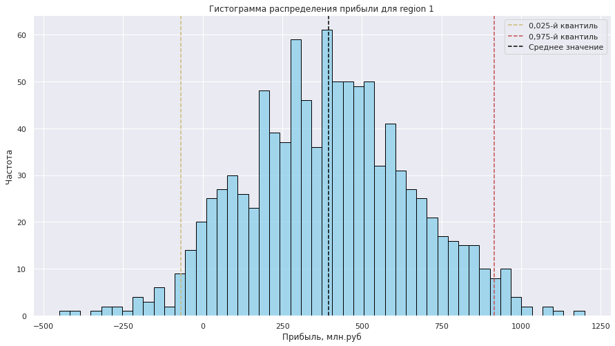

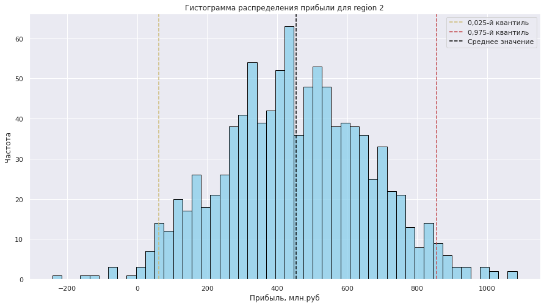

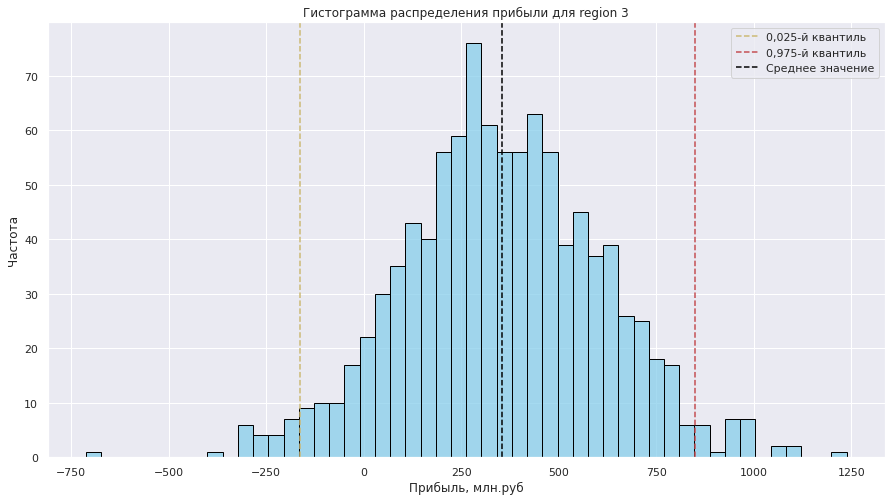

```python
for region in region_income_data.columns:
    reg = region_income_data[region]

    plt.figure(figsize=(15, 8))

    sns.histplot(data=reg, bins=50, color='skyblue', edgecolor='black')
    plt.axvline(x=reg.quantile(0.025), color='y', linestyle='--', label='0,025-й квантиль')
    plt.axvline(x=reg.quantile(0.975), color='r', linestyle='--', label='0,975-й квантиль')
    plt.axvline(x=reg.mean(), color='black', linestyle='--', label='Среднее значение')
    plt.title(f'Гистограмма распределения прибыли для {region}')
    plt.ylabel('Частота')
    plt.xlabel('Прибыль, млн.руб')
    plt.legend()

    plt.show()
```

Из всех регионов только лишь второй имеет риск убытков меньше, чем 2,5%. Также второй регион имеет наибольшую среднюю прибыль от реализации нефти (454,7 млн.руб), а его доверительный интервал не включает отрицательных значений. Поэтому для дальнейшей разработки выбираем **второй** регион.